# Facteurs associés à l’accident vasculaire cérébral chez les adultes : une analyse multivariée

Analyse transversale du jeu de données de prédiction des AVC de Kaggle

Auteur·rice

Jiahui YI / Jade YI

Date de publication

20 septembre 2026

# 1 Introduction et objectifs

Cette analyse observationnelle est rapportée conformément aux recommandations STROBE (Elm et al. 2007).

## 1.1 Objectifs de l’analyse

L’objectif principal est d’étudier les facteurs associés à la présence d’un antécédent d’AVC chez les adultes de ce jeu de données.

## 1.2 Méthode

L’analyse repose sur une régression logistique multivariée (voir la section Méthodes statistiques). Il s’agit d’une analyse observationnelle : les associations mises en évidence ne permettent pas, à elles seules, de conclure à un lien causal.

# 2 Hypothèses a priori

Les hypothèses ont été formulées avant l’analyse statistique.[^1]

**H1 (âge).** Association positive forte avec l’AVC, qui devrait rester importante après ajustement. **H2 (hypertension).** Association positive relativement forte en analyse brute. Elle pourrait diminuer après ajustement (âge, IMC, glycémie), mais l’hypertension devrait rester associée à l’AVC. **H3 (glycémie moyenne).** Association positive d’intensité modérée, en partie liée à l’âge, à l’IMC et à l’hypertension. **H4 (IMC).** Association positive relativement forte, susceptible de diminuer après ajustement sur l’âge, l’hypertension et la glycémie. Une relation non strictement linéaire est possible. **H5 (tabagisme).** Probabilité d’AVC plus élevée chez les fumeurs actuels et anciens que chez les personnes n’ayant jamais fumé (association relativement forte), en partie expliquée par l’âge et l’état de santé. La modalité « Inconnu » est à interpréter avec prudence. **H6 (type d’emploi).** Pas de relation directe forte. Des différences brutes pourraient apparaître et diminuer après ajustement. Variable considérée comme exploratoire. **H7 (lieu de résidence).** Association faible, voire inexistante. **H8 (statut marital).** Association brute modérée, avec davantage d’AVC chez les personnes déjà mariées, principalement parce qu’elles sont plus âgées. Elle devrait diminuer fortement, voire disparaître, après ajustement sur l’âge. **H9 (maladie cardiaque).** Association positive forte, qui devrait diminuer partiellement après ajustement (âge, hypertension, glycémie, tabagisme) tout en restant importante. **H10 (genre).** Probabilité d’AVC plus élevée chez les hommes en analyse brute. Le tabagisme pourrait être un médiateur plutôt qu’un facteur de confusion, de sorte que l’association pourrait diminuer après ajustement sur le tabagisme.

# 3 Source des données

Les données proviennent du jeu de données public *Stroke Prediction Dataset*, diffusé sur la plateforme Kaggle (fichier `healthcare-dataset-stroke-data.csv`). Chaque ligne correspond à un individu, décrit par :

- des caractéristiques démographiques (âge, sexe, statut marital, type d’emploi, lieu de résidence) ;
- des caractéristiques cliniques (hypertension, maladie cardiaque, glycémie moyenne, indice de masse corporelle) ;
- un comportement (statut tabagique) ;
- la présence ou non d’un antécédent d’AVC.

```r
donnees <- read_csv(
  "data/raw/healthcare-dataset-stroke-data.csv",
  na = c("", "NA", "N/A")
)
```

## 3.1 Structure initiale

```r
n_total <- nrow(donnees)
n_avc   <- sum(donnees$stroke == 1)
n_non   <- n_total - n_avc
prop_avc <- n_avc / n_total
```

Le fichier brut contient 5110 individus et 12 variables. L’identifiant id est unique pour chaque individu.

### 3.1.1 Répartition de l’AVC dans le fichier brut

```r
donnees |>
  count(stroke) |>
  mutate(
    AVC = if_else(stroke == 1, "Oui", "Non"),
    Proportion = scales::percent(n / sum(n), accuracy = 0.01)
  ) |>
  select(AVC, Effectif = n, Proportion) |>
  knitr::kable()
```

| AVC | Effectif | Proportion |
| --- | --- | --- |
| Non | 4861 | 95.13% |
| Oui | 249 | 4.87% |

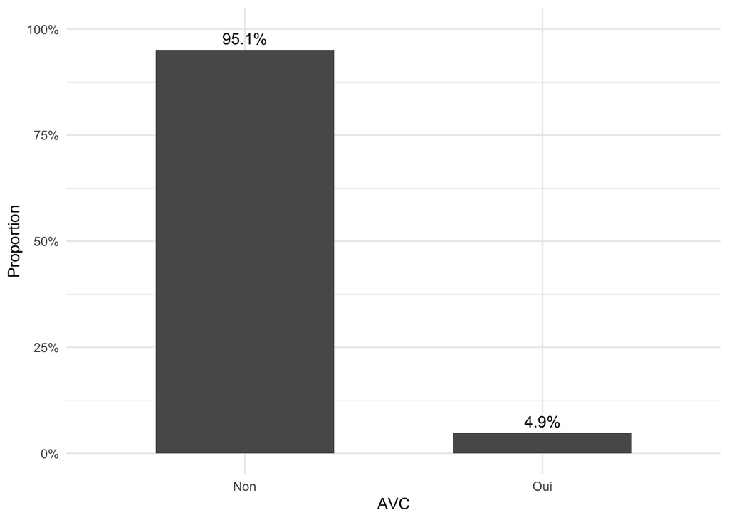

Répartition du statut AVC dans le fichier brut

```r
donnees |>
  count(stroke) |>
  mutate(
    AVC = if_else(stroke == 1, "Oui", "Non"),
    proportion = n / sum(n)) |>
  ggplot(aes(x = AVC, y = proportion)) +
  geom_col(width = 0.6) +
  geom_text( aes(label = scales::percent(proportion, accuracy = 0.1)),
    vjust = -0.5) +
  scale_y_continuous(
    labels = scales::percent,
    limits = c(0, 1)) +
  labs(x = "AVC", y = "Proportion") +
  theme_minimal()
```

Dans le fichier brut, 249 individus sur 5110 présentent un statut AVC positif, soit 4.9%.

Cette proportion décrit la composition de l’échantillon et ne constitue pas une estimation de prévalence.

# 4 Évaluation initiale de la qualité des données

## 4.1 Valeurs manquantes

```r
donnees |>
  summarise(across(everything(), ~ sum(is.na(.)))) |>
  pivot_longer(everything(), names_to = "Variable", values_to = "n_manquant") |>
  filter(n_manquant > 0) |>
  mutate(Pourcentage = scales::percent(n_manquant / nrow(donnees), accuracy = 0.1)) |>
  rename(`Valeurs manquantes` = n_manquant) |>
  knitr::kable()
```

| Variable | Valeurs manquantes | Pourcentage |
| --- | --- | --- |
| bmi | 201 | 3.9% |

Seule la variable `bmi` comporte des valeurs manquantes au sens strict (codées `NA`). Les autres variables ne présentent aucune valeur manquante déclarée.

**Cas particulier de `smoking_status`.** Cette variable comporte une modalité `"Unknown"`, qui correspond fonctionnellement à une information manquante mais qui n’est pas codée comme `NA` dans le fichier source. Elle est conservée comme catégorie à part entière dans le modèle.

## 4.2 Valeurs incohérentes ou improbables

```r
donnees |>
  reframe(across(
    c(age, bmi, avg_glucose_level),
    ~ c(min(.x, na.rm = TRUE),
        quantile(.x, 0.25, na.rm = TRUE),
        median(.x, na.rm = TRUE),
        quantile(.x, 0.75, na.rm = TRUE),
        max(.x, na.rm = TRUE))
  )) |>
  mutate(Statistique = c("Min", "Q1", "Médiane", "Q3", "Max"), .before = 1) |>
  knitr::kable(digits = 1)
```

| Statistique | age | bmi | avg_glucose_level |
| --- | --- | --- | --- |
| Min | 0.1 | 10.3 | 55.1 |
| Q1 | 25.0 | 23.5 | 77.2 |
| Médiane | 45.0 | 28.1 | 91.9 |
| Q3 | 61.0 | 33.1 | 114.1 |
| Max | 82.0 | 97.6 | 271.7 |

L’examen de la distribution des variables quantitatives ne révèle pas de valeur impossible évidente (âge négatif, IMC ou glycémie nul, etc.). Deux points méritent toutefois d’être signalés :

```r
donnees |> count(gender) |> knitr::kable()
```

| gender | n |
| --- | --- |
| Female | 2994 |
| Male | 2115 |
| Other | 1 |

```r
donnees |>
  filter(
    (age < 18 & ever_married == "Yes") |
    (age < 18 & work_type %in% c("Govt_job", "Private", "Self-employed"))
  ) |>
  select(id, age, ever_married, work_type)
```

```
# A tibble: 152 × 4
      id   age ever_married work_type
   <dbl> <dbl> <chr>        <chr>
 1 16523     8 No           Private
 2 26325    14 No           Govt_job
 3 70970    17 No           Self-employed
 4 23462    17 No           Private
 5 54975     7 No           Self-employed
 6  7351    13 No           Private
 7 43134    16 No           Private
 8 31145    17 No           Private
 9 54182    16 No           Private
10 16575    17 No           Private
# ℹ 142 more rows
```

La variable `gender` ne compte qu’une seule observation `"Other"`, effectif insuffisant pour l’analyse ; cette observation sera exclue.

# 5 Définition de la population analytique et préparation des données

L’analyse porte uniquement sur les adultes : les individus âgés de moins de 18 ans sont exclus, car le mécanisme et les facteurs de risque de l’AVC diffèrent fortement chez l’enfant, et plusieurs variables (`work_type`, `ever_married`) n’ont pas de sens pour cette population.

La modalité Never_worked ne comprend que cinq adultes, sans aucun cas d’AVC, entraînant un phénomène de séparation dans la régression logistique. Ces cinq observations ont donc été exclues de l’analyse.

```r
donnees_adultes_brut <- donnees |>
  filter(age >= 18)

donnees_adultes <- donnees_adultes_brut |>
  filter(gender != "Other",work_type != "Never_worked" ) |>
  mutate(
    gender = droplevels(as.factor(gender)),
    work_type = droplevels(as.factor(work_type))
  )

n_adultes <- nrow(donnees_adultes_brut)
n_avc_adultes <- sum(donnees_adultes_brut$stroke == 1)
prop_avc_adultes <- n_avc_adultes / n_adultes
n_exclus_age    <- sum(donnees$age < 18)
n_exclus_gender <- sum(donnees$age >= 18 & donnees$gender == "Other")
n_exclus_never_worked<- sum(donnees_adultes_brut$work_type=="Never_worked")
n_analyse <- nrow(donnees_adultes)

tibble::tibble(
  Étape = c("Fichier initial", "Âge < 18", "Genre = Other",
            "Never worked", "Échantillon final"),
  Exclus   = c(NA, n_exclus_age, n_exclus_gender, n_exclus_never_worked, NA),
  Restants = c(n_total, n_total - n_exclus_age,
               n_total - n_exclus_age - n_exclus_gender,n_analyse,
               n_analyse)) |>
  knitr::kable(
    col.names = c("Étape", "Nombre exclu", "Effectif restant"),
    format.args = list(big.mark = " ")
  )
```

| Étape | Nombre exclu | Effectif restant |
| --- | --- | --- |
| Fichier initial | NA | 5 110 |
| Âge < 18 | 856 | 4 254 |
| Genre = Other | 1 | 4 253 |
| Never worked | 5 | 4 248 |
| Échantillon final | NA | 4 248 |

### 5.0.1 Mise en perspective avec les données françaises

À titre de repère externe, Santé publique France estime qu’environ 2,0 % de la population adulte française avait un antécédent d’AVC au 1er janvier 2023 (Gabet et al. 2025). Dans le présent jeu de données, la proportion d’adultes avec un statut AVC positif est de 5.8%.

Ces valeurs ne sont pas comparables : l’estimation de Santé publique France concerne une population nationale définie, alors que la population source, le mode de constitution et la représentativité du jeu de données sont inconnus (voir la section Limites).

### 5.0.2 Préparation des variables

Les valeurs manquantes de l’IMC ont été remplacées par la médiane. Une seconde version de l’IMC, winsorisée aux 2,5e et 97,5e percentiles, a également été créée pour l’analyse de sensibilité. La glycémie moyenne a été divisée par 10 afin d’exprimer son OR par augmentation de 10 mg/dL.

```r
mediane_bmi <- median(donnees_adultes$bmi, na.rm = TRUE)
seuil_bas   <- quantile(donnees_adultes$bmi, 0.025, na.rm = TRUE)
seuil_haut  <- quantile(donnees_adultes$bmi, 0.975, na.rm = TRUE)


donnees_adultes <- donnees_adultes |>
  mutate(
    bmi = if_else(is.na(bmi), mediane_bmi, bmi),
    bmi_wins = case_when(
      bmi < seuil_bas  ~ seuil_bas,
      bmi > seuil_haut ~ seuil_haut,
      TRUE ~ bmi
    ),
    glucose_10 = avg_glucose_level / 10,
    stroke        = factor(stroke, levels = c(0, 1), labels = c("Non", "Oui")),
    hypertension  = factor(hypertension, levels = c(0, 1), labels = c("Non", "Oui")),
    heart_disease = factor(heart_disease, levels = c(0, 1), labels = c("Non", "Oui")),

gender = fct_recode(gender,
      "Femme" = "Female",
      "Homme" = "Male"
    ),
    ever_married = fct_recode(as.factor(ever_married),
      "Non" = "No",
      "Oui" = "Yes"
    ),
    work_type = fct_recode(work_type,
      "Fonction publique" = "Govt_job",
      "Secteur privé"     = "Private",
      "Indépendant"       = "Self-employed"
    ),
    Residence_type = fct_recode(as.factor(Residence_type),
      "Rurale" = "Rural",
      "Urbaine" = "Urban"
    ),
    smoking_status = fct_recode(as.factor(smoking_status),
      "Ancien fumeur" = "formerly smoked",
      "Jamais fumé"   = "never smoked",
      "Fumeur actuel" = "smokes",
      "Inconnu"       = "Unknown"
    )
  )
```

# 6 Méthodes statistiques

Les caractéristiques de la population sont d’abord décrites selon le statut AVC (tableau 1), puis les associations avec l’AVC sont évaluées conjointement par régression logistique multivariée. Les résultats sont exprimés en *odds ratios* (OR) ajustés avec leur intervalle de confiance à 95 %. Le seuil de significativité est fixé à 0,05.

Le modèle multivarié inclut l’ensemble des variables décrites au tableau 1, afin de décrire les associations conjointes avec l’AVC dans cet échantillon.

Les variables continues sont présentées en moyenne (écart-type) et comparées par test t de Student ; les variables catégorielles sont présentées en effectif (pourcentage) et comparées par test du χ² (ou test exact de Fisher en cas d’effectifs attendus trop faibles).

Le modèle logistique principal suppose une relation linéaire entre les variables continues et le log-odds d’AVC. Cette hypothèse a été examinée pour l’âge, l’IMC et la glycémie moyenne en comparant, pour chaque variable, le modèle linéaire à un modèle utilisant un spline naturel à trois degrés de liberté. Les modèles ont été comparés par un test du rapport de vraisemblance.

## 6.1 Représentation conceptuelle des relations hypothétiques (DAG)

Le schéma ci-dessous représente les relations hypothétiques entre les variables et illustre notamment le rôle central de l’âge. Il constitue un support conceptuel et n’a pas été utilisé pour définir un ajustement causal.

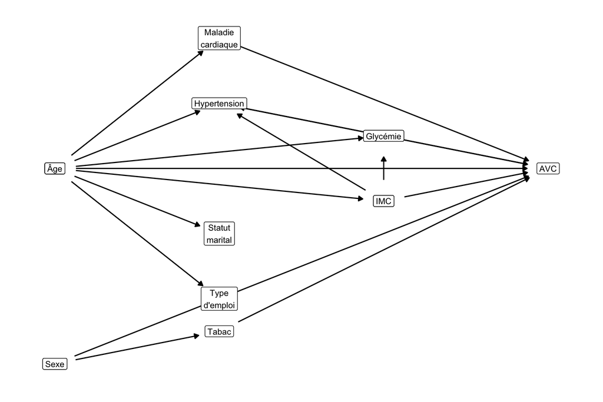

Représentation conceptuelle des relations hypothétiques entre les variables

```r
coords <- list(
  x = c(age = 2, hypertension = 3, heart_disease = 3, ever_married = 3,
        work_type = 3, gender = 2, smoking = 3, avg_glucose_level = 4,
        bmi = 4, stroke = 5),
  y = c(age = 3, hypertension = 4, heart_disease = 5, ever_married = 2,
        work_type = 1, gender = 0, smoking = 0.5, avg_glucose_level = 3.5,
        bmi = 2.5, stroke = 3))

dag_avc <- dagify(
  stroke ~ age + hypertension + heart_disease + avg_glucose_level + bmi + smoking + gender,
  hypertension ~ age + bmi + avg_glucose_level,
  heart_disease ~ age,
  avg_glucose_level ~ age + bmi,
  bmi ~ age,
  ever_married ~ age,
  work_type ~ age,
  smoking ~ gender,
  coords = coords,
  labels = c(
    stroke  = "AVC",
    age = "Âge",
    gender = "Sexe",
    hypertension = "Hypertension",
    heart_disease  = "Maladie\ncardiaque",
    avg_glucose_level  = "Glycémie",
    bmi  = "IMC",
    smoking  = "Tabac",
    ever_married  = "Statut\nmarital",
    work_type = "Type\nd'emploi"
  )
)

ggplot(dag_avc, aes(x = x, y = y, xend = xend, yend = yend)) +
  geom_dag_edges() +
  geom_label(aes(label = label), na.rm = TRUE, size = 3.2) +
  theme_dag()
```

# 7 Résultats

## 7.1 Description de la population

Le tableau 1 décrit les caractéristiques de la population analytique selon la survenue ou non d’un AVC.

```r
donnees_adultes |>
  select(
    stroke, age, gender, hypertension, heart_disease,
    ever_married, work_type, Residence_type,
    glucose_10, bmi, smoking_status
  ) |>
  tbl_summary(
    by = stroke,
    label = list(
      age  ~ "Âge (années)",
      gender ~ "Sexe",
      hypertension ~ "Hypertension",
      heart_disease  ~ "Maladie cardiaque",
      ever_married ~ "Déjà marié(e)",
      work_type ~ "Type d'emploi",
      Residence_type ~ "Lieu de résidence",
      glucose_10  ~ "Glycémie moyenne (10mg/dL)",
      bmi ~ "IMC (kg/m²)",
      smoking_status ~ "Statut tabagique"
    ),
    value = list(
      hypertension  ~ "Oui",
      heart_disease ~ "Oui"
    ),
    statistic = list(
      all_continuous()  ~ "{mean} ({sd})",
      all_categorical() ~ "{n} ({p}%)"
    ),
    digits = all_continuous() ~ 1
  ) |>
  add_p(test = list(all_continuous() ~ "t.test")) |>
  add_overall() |>
  modify_header(label ~ "**Variable**") |>
  modify_caption("**Tableau 1.** Caractéristiques de la population selon le statut AVC")
```

**Tableau 1.** Caractéristiques de la population selon le statut AVC

| **Variable** | **Overall** N = 4,248<sup>1</sup> | **Non** N = 4,001<sup>1</sup> | **Oui** N = 247<sup>1</sup> | **p-value**<sup>2</sup> |
| --- | --- | --- | --- | --- |
| Âge (années) | 50.2 (17.8) | 49.1 (17.5) | 68.2 (11.6) | <0.001 |
| Sexe |  |  |  | 0.2 |
| Femme | 2,572 (61%) | 2,433 (61%) | 139 (56%) |  |
| Homme | 1,676 (39%) | 1,568 (39%) | 108 (44%) |  |
| Hypertension | 497 (12%) | 431 (11%) | 66 (27%) | <0.001 |
| Maladie cardiaque | 275 (6.5%) | 228 (5.7%) | 47 (19%) | <0.001 |
| Déjà marié(e) |  |  |  | <0.001 |
| Non | 895 (21%) | 868 (22%) | 27 (11%) |  |
| Oui | 3,353 (79%) | 3,133 (78%) | 220 (89%) |  |
| Type d'emploi |  |  |  | 0.010 |
| Fonction publique | 651 (15%) | 618 (15%) | 33 (13%) |  |
| Secteur privé | 2,790 (66%) | 2,641 (66%) | 149 (60%) |  |
| Indépendant | 807 (19%) | 742 (19%) | 65 (26%) |  |
| Lieu de résidence |  |  |  | 0.3 |
| Rurale | 2,084 (49%) | 1,971 (49%) | 113 (46%) |  |
| Urbaine | 2,164 (51%) | 2,030 (51%) | 134 (54%) |  |
| Glycémie moyenne (10mg/dL) | 10.9 (4.8) | 10.7 (4.6) | 13.3 (6.2) | <0.001 |
| IMC (kg/m²) | 30.4 (7.1) | 30.4 (7.2) | 30.3 (5.8) | 0.7 |
| Statut tabagique |  |  |  | 0.013 |
| Ancien fumeur | 859 (20%) | 789 (20%) | 70 (28%) |  |
| Jamais fumé | 1,749 (41%) | 1,659 (41%) | 90 (36%) |  |
| Fumeur actuel | 780 (18%) | 738 (18%) | 42 (17%) |  |
| Inconnu | 860 (20%) | 815 (20%) | 45 (18%) |  |

<sup>1</sup> Mean (SD); n (%)  
<sup>2</sup> Welch Two Sample t-test; Pearson’s Chi-squared test

## 7.2 Modèle multivarié

### 7.2.1 Linéarité des variables continues sur l’échelle du logit

```r
modele_principal <- glm(
  stroke ~ age + gender + hypertension + heart_disease + ever_married +
    work_type + Residence_type + glucose_10 + bmi + smoking_status,
  data = donnees_adultes,
  family = binomial(link = "logit"))

modele_age_spline     <- update(modele_principal, . ~ . - age + ns(age, df = 3))
modele_bmi_spline     <- update(modele_principal, . ~ . - bmi + ns(bmi, df = 3))
modele_glucose_spline <- update(modele_principal, . ~ . - glucose_10 + ns(glucose_10, df = 3))

lrt_age <-anova(modele_principal, modele_age_spline, test = "LRT")
lrt_bmi <-anova(modele_principal, modele_bmi_spline, test = "LRT")
lrt_glucose <-anova(modele_principal, modele_glucose_spline, test = "LRT")
p_age     <- lrt_age[2, "Pr(>Chi)"]
p_bmi     <- lrt_bmi[2, "Pr(>Chi)"]
p_glucose <- lrt_glucose[2, "Pr(>Chi)"]

fmt_p <- function(p) {
  ifelse(p < 0.001, "p < 0,001",
         paste0("p = ", formatC(p, format = "f", digits = 3, decimal.mark = ",")))
}
```

Une amélioration de l’ajustement a été observée pour l’âge (p = 0,012), mais pas pour l’IMC (p = 0,264) ni pour la glycémie moyenne (p = 0,678). L’exploration de la forme fonctionnelle a donc été poursuivie pour l’âge.

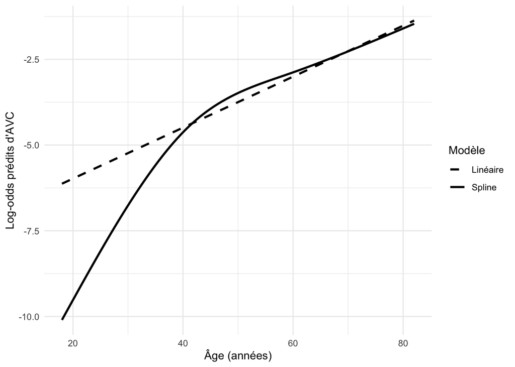

```r
age_seq <- seq(
  min(donnees_adultes$age, na.rm = TRUE),
  max(donnees_adultes$age, na.rm = TRUE),
  length.out = 200
)

newdata_age <- data.frame(
  age = age_seq,
  gender = factor("Femme", levels = levels(donnees_adultes$gender)),
  hypertension = factor("Non", levels = levels(donnees_adultes$hypertension)),
  heart_disease = factor("Non", levels = levels(donnees_adultes$heart_disease)),
  ever_married = factor("Oui", levels = levels(donnees_adultes$ever_married)),
  work_type = factor("Secteur privé", levels = levels(donnees_adultes$work_type)),
  Residence_type = factor("Urbaine", levels = levels(donnees_adultes$Residence_type)),
  glucose_10 = median(donnees_adultes$glucose_10, na.rm = TRUE),
  bmi = median(donnees_adultes$bmi, na.rm = TRUE),
  smoking_status = factor(
    "Jamais fumé",
    levels = levels(donnees_adultes$smoking_status)
  )
)
newdata_age$lineaire_logit <- predict(
  modele_principal,
  newdata = newdata_age,
  type = "link"
)

newdata_age$spline_logit <- predict( modele_age_spline,newdata = newdata_age,type = "link")

newdata_age |>
  select(age, lineaire_logit, spline_logit) |>
  pivot_longer(cols = c(lineaire_logit, spline_logit),names_to = "modele",values_to = "log_odds") |>
  ggplot(aes(x = age,y = log_odds,linetype = modele)) +
  geom_line(linewidth = 1) +scale_linetype_manual(values = c("lineaire_logit" = "dashed","spline_logit" = "solid"),
    labels = c("lineaire_logit" = "Linéaire",
  "spline_logit" = "Spline")) +
  labs(x = "Âge (années)", y = "Log-odds prédits d'AVC",
    linetype = "Modèle") +theme_minimal()
```

Sur l’échelle du logit, l’écart entre les deux spécifications est plus visible aux âges les plus jeunes. Au-delà d’environ 40 ans, les deux courbes se rapprochent progressivement.

La répartition des événements par groupe d’âge a ensuite été examinée pour interpréter cette déviation dans le contexte des données observées.

```r
donnees_adultes |>
  mutate(
    age_group = cut(
      age,
      breaks = c(18, 30, 40, 50, 60, 70, 80, Inf),
      right = FALSE
    )
  ) |>
  count(age_group, stroke) |>
  tidyr::pivot_wider(
    names_from = stroke,
    values_from = n,
    values_fill = 0
  )
```

```
# A tibble: 7 × 3
  age_group   Non   Oui
  <fct>     <int> <int>
1 [18,30)     653     0
2 [30,40)     649     6
3 [40,50)     718    12
4 [50,60)     786    48
5 [60,70)     574    47
6 [70,80)     475    94
7 [80,Inf)    146    40
```

Aucun AVC n’est observé parmi les 653 participants âgés de 18 à 29 ans, et seuls 6 événements sont observés entre 30 et 39 ans. La déviation observée aux âges les plus jeunes concerne donc une partie de l’échantillon où les événements sont très rares.

Les estimations des autres covariables ont également été comparées entre les deux modèles.

```r
tbl_merge(tbls = list(tbl_regression(modele_principal,
      exponentiate = TRUE),
    tbl_regression(modele_age_spline,exponentiate = TRUE)),
  tab_spanner = c(
    "**Âge linéaire**",
    "**Âge avec spline**" ))
```

[output not shown]

### 7.2.2 Modèle logistique multivarié

```r
tbl_regression(
  modele_principal,
  exponentiate = TRUE,
  label = list(
    age               ~ "Âge (années)",
    gender            ~ "Sexe",
    hypertension      ~ "Hypertension",
    heart_disease     ~ "Maladie cardiaque",
    ever_married      ~ "Déjà marié(e)",
    work_type         ~ "Type d'emploi",
    Residence_type    ~ "Lieu de résidence",
    glucose_10 ~ "Glycémie moyenne (par +10 mg/dL)",
    bmi               ~ "IMC (kg/m²)",
    smoking_status    ~ "Statut tabagique"
  )
) |>
  modify_column_merge(
    pattern = "[{conf.low} - {conf.high}]",
    rows = !is.na(conf.low)
  ) |>
  modify_header(
    label    ~ "**Variable**",
    estimate ~ "**OR**",
    conf.low ~ "**IC à 95 %**",
    p.value  ~ "**p**"
  ) |>
  remove_abbreviation() |>
  modify_footnote_header(
    footnote = "OR = odds ratio ajusté ; IC = intervalle de confiance.",
    columns = c(estimate, conf.low)
  ) |>
  modify_source_note(
    "Modèle ajusté pour l'âge, le sexe, l'hypertension, la maladie cardiaque, le statut marital, le type d'emploi, le lieu de résidence, la glycémie moyenne, l'IMC et le statut tabagique."
  ) |>
  modify_caption("**Tableau 2.** Odds ratios ajustés (IC à 95 %) de l'association avec l'AVC")
```

**Tableau 2.** Odds ratios ajustés (IC à 95 %) de l’association avec l’AVC

| **Variable** | **OR**<sup>1</sup> | **IC à 95 %**<sup>1</sup> | **p** |
| --- | --- | --- | --- |
| Âge (années) | 1.08 | [1.07 - 1.09] | <0.001 |
| Sexe |  |  |  |
| Femme | — | — |  |
| Homme | 1.03 | [0.78 - 1.37] | 0.8 |
| Hypertension |  |  |  |
| Non | — | — |  |
| Oui | 1.49 | [1.07 - 2.05] | 0.015 |
| Maladie cardiaque |  |  |  |
| Non | — | — |  |
| Oui | 1.32 | [0.90 - 1.90] | 0.15 |
| Déjà marié(e) |  |  |  |
| Non | — | — |  |
| Oui | 0.82 | [0.53 - 1.30] | 0.4 |
| Type d'emploi |  |  |  |
| Fonction publique | — | — |  |
| Secteur privé | 1.16 | [0.78 - 1.76] | 0.5 |
| Indépendant | 0.79 | [0.51 - 1.27] | 0.3 |
| Lieu de résidence |  |  |  |
| Rurale | — | — |  |
| Urbaine | 1.09 | [0.83 - 1.43] | 0.5 |
| Glycémie moyenne (par +10 mg/dL) | 1.04 | [1.02 - 1.07] | <0.001 |
| IMC (kg/m²) | 1.00 | [0.98 - 1.02] | 0.9 |
| Statut tabagique |  |  |  |
| Ancien fumeur | — | — |  |
| Jamais fumé | 0.82 | [0.58 - 1.16] | 0.3 |
| Fumeur actuel | 1.12 | [0.73 - 1.70] | 0.6 |
| Inconnu | 0.93 | [0.61 - 1.39] | 0.7 |

<sup>1</sup> OR = odds ratio ajusté ; IC = intervalle de confiance.  
Modèle ajusté pour l’âge, le sexe, l’hypertension, la maladie cardiaque, le statut marital, le type d’emploi, le lieu de résidence, la glycémie moyenne, l’IMC et le statut tabagique.

Après ajustement, l’âge (OR = 1,08 par année ; IC à 95 % : 1,07–1,09 ; p < 0,001), l’hypertension (OR = 1,49 ; IC à 95 % : 1,07–2,05 ; p = 0,015) et la glycémie moyenne (OR = 1,04 par augmentation de 10 mg/dL ; IC à 95 % : 1,02–1,07 ; p < 0,001) étaient significativement associés à la présence d’un antécédent d’AVC.

Aucune association statistiquement significative n’était observée pour les autres covariables. En particulier, l’association observée entre la maladie cardiaque et l’antécédent d’AVC dans les comparaisons bivariées n’était plus significative après ajustement (OR = 1,32 ; IC à 95 % : 0,90–1,90 ; p = 0,15).

## 7.3 Analyse de sensibilité : winsorisation de l’IMC

```r
# Modèle de sensibilité
modele_bmi_wins <- glm(
  stroke ~ age + gender + hypertension + heart_disease + ever_married +
    work_type + Residence_type + glucose_10 + bmi_wins + smoking_status,
  data = donnees_adultes,
  family = binomial(link = "logit")
)

# Résultats du modèle principal
res_principal <- tidy(
  modele_principal,
  exponentiate = TRUE,
  conf.int = TRUE
) |>
  filter(term %in% c(
    "age", "hypertensionOui", "glucose_10", "bmi"
  )) |>
  mutate(
    Variable = case_when(
      term == "age" ~ "Âge (par année)",
      term == "hypertensionOui" ~ "Hypertension (Oui vs Non)",
      term == "glucose_10" ~ "Glycémie moyenne (par +10 mg/dL)",
      term == "bmi" ~ "IMC"
    ),
    principal = sprintf(
      "%.2f [%.2f–%.2f]",
      estimate, conf.low, conf.high
    )
  ) |>
  select(Variable, principal)

# Résultats du modèle de sensibilité
res_sensibilite <- tidy(
  modele_bmi_wins,
  exponentiate = TRUE,
  conf.int = TRUE
) |>
  filter(term %in% c(
    "age", "hypertensionOui", "glucose_10", "bmi_wins"
  )) |>
  mutate(
    Variable = case_when(
      term == "age" ~ "Âge (par année)",
      term == "hypertensionOui" ~ "Hypertension (Oui vs Non)",
      term == "glucose_10" ~ "Glycémie moyenne (par +10 mg/dL)",
      term == "bmi_wins" ~ "IMC"
    ),
    sensibilite = sprintf(
      "%.2f [%.2f–%.2f]",
      estimate, conf.low, conf.high
    )
  ) |>
  select(Variable, sensibilite)

# Tableau comparatif
left_join(
  res_principal,
  res_sensibilite,
  by = "Variable"
) |>
  gt::gt() |>
  gt::cols_label(
    Variable = "Variable",
    principal = "Analyse principale",
    sensibilite = "Analyse de sensibilité"
  ) |>
  gt::tab_header(
    title = gt::md(
      "**Tableau 3. Comparaison du modèle principal et de l'analyse de sensibilité**"
    )
  )
```

**Tableau 3. Comparaison du modèle principal et de l’analyse de sensibilité**

| Variable | Analyse principale | Analyse de sensibilité |
| --- | --- | --- |
| Âge (par année) | 1.08 [1.07–1.09] | 1.08 [1.07–1.09] |
| Hypertension (Oui vs Non) | 1.49 [1.07–2.05] | 1.49 [1.07–2.05] |
| Glycémie moyenne (par +10 mg/dL) | 1.04 [1.02–1.07] | 1.04 [1.02–1.07] |
| IMC | 1.00 [0.98–1.02] | 1.00 [0.98–1.03] |

Les estimations sont très proches entre les deux modèles, indiquant une faible influence des valeurs extrêmes d’IMC sur les résultats.

## 7.4 Représentation graphique des résultats

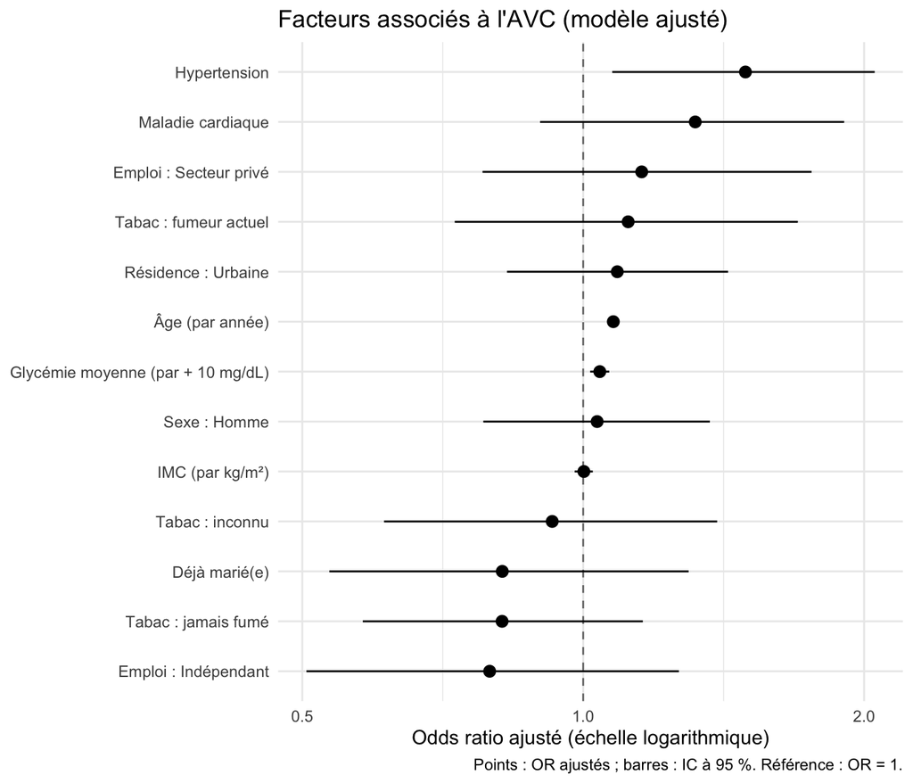

Odds ratios ajustés (IC à 95 %) du modèle principal

```r
etiquettes <- c(
  age  = "Âge (par année)",
  genderHomme   = "Sexe : Homme",
  hypertensionOui  = "Hypertension",
  heart_diseaseOui = "Maladie cardiaque",
  ever_marriedOui  = "Déjà marié(e)",
  `work_typeSecteur privé` = "Emploi : Secteur privé",
  work_typeIndépendant = "Emploi : Indépendant",
  Residence_typeUrbaine  = "Résidence : Urbaine",
  glucose_10  = "Glycémie moyenne (par + 10 mg/dL)",
  bmi  = "IMC (par kg/m²)",
  `smoking_statusJamais fumé` = "Tabac : jamais fumé",
  `smoking_statusFumeur actuel` = "Tabac : fumeur actuel",
  smoking_statusInconnu = "Tabac : inconnu"
)

resultats_modele <- tidy(modele_principal, exponentiate = TRUE, conf.int = TRUE) |>
  filter(term != "(Intercept)") |>
  mutate(term = recode(term, !!!etiquettes))

ggplot(resultats_modele, aes(x = estimate, y = fct_reorder(term, estimate))) +
  geom_vline(xintercept = 1, linetype = "dashed", color = "grey50") +
  geom_pointrange(aes(xmin = conf.low, xmax = conf.high)) +
  scale_x_log10() +
  labs(
    x = "Odds ratio ajusté (échelle logarithmique)",
    y = NULL,
    title = "Facteurs associés à l'AVC (modèle ajusté)",
    caption = "Points : OR ajustés ; barres : IC à 95 %. Référence : OR = 1."
  ) +
  theme_minimal()
```

La figure ci-dessus récapitule les OR ajustés du modèle principal (Tableau 2).

# 8 Discussion

## 8.1 Confrontation aux hypothèses

Les résultats sont globalement concordants avec les hypothèses concernant l’âge, l’hypertension et la glycémie moyenne, qui restent associés à l’antécédent d’AVC après ajustement. L’absence d’association avec le lieu de résidence et le type d’emploi est également conforme aux hypothèses initiales.

Le statut marital et la maladie cardiaque présentaient des associations descriptives qui n’étaient plus mises en évidence après ajustement. Pour le statut marital, cette atténuation était attendue compte tenu de sa forte relation avec l’âge. Pour la maladie cardiaque, elle était plus importante qu’anticipé ; l’estimation restait néanmoins orientée vers une association positive, avec une incertitude importante.

En revanche, les associations attendues pour l’IMC, le tabagisme et le sexe n’ont pas été mises en évidence. Pour l’IMC, les résultats étaient similaires après winsorisation et aucune amélioration de l’ajustement n’était observée avec le spline, ce qui ne suggère pas que ce résultat soit principalement expliqué par les valeurs extrêmes ou par une non-linéarité simple. Pour le tabagisme, l’interprétation est notamment limitée par la catégorie « Inconnu » et par l’absence d’information sur la temporalité de l’exposition.

## 8.2 Limites

**Temporalité des mesures** La date de survenue de l’AVC et le moment de mesure des autres variables ne sont pas renseignés. La séquence temporelle ne peut donc pas être établie, ce qui exclut toute interprétation causale.

**Définition et mesure des variables** Les modalités de définition ou de mesure de plusieurs variables, notamment l’AVC, l’hypertension, les maladies cardiaques et la glycémie, sont insuffisamment documentées. Des erreurs de classification ou de mesure ne peuvent donc pas être exclues.

**Représentativité de l’échantillon** La population source, le mode d’échantillonnage et les modalités de recrutement ne sont pas documentés. La proportion d’antécédents d’AVC ne peut donc pas être interprétée comme une prévalence en population générale, et la généralisation des résultats reste limitée.

**Données manquantes de l’IMC** Les valeurs manquantes ont été remplacées par la médiane, une méthode qui réduit artificiellement la variabilité et ne tient pas compte de l’incertitude liée à l’imputation. Les estimations concernant l’IMC peuvent donc en être affectées.

**Confusion résiduelle** L’ajustement étant limité aux variables disponibles, l’influence de facteurs non mesurés ne peut pas être exclue.

# 9 Conclusion

Dans cet échantillon, l’âge, l’hypertension et la glycémie moyenne étaient associés à la présence d’un antécédent d’AVC après ajustement. Les associations descriptives observées pour la maladie cardiaque et le statut marital étaient atténuées dans le modèle multivarié, tandis qu’aucune association n’était mise en évidence pour les autres variables étudiées. Ces résultats décrivent les associations observées dans cet échantillon et ne permettent pas d’inférence causale.

## Les références

Elm, Erik von, Douglas G. Altman, Matthias Egger, Stuart J. Pocock, Peter C. Gøtzsche, et Jan P. Vandenbroucke. 2007. « The Strengthening the Reporting of Observational Studies in Epidemiology (STROBE) Statement: Guidelines for Reporting Observational Studies ». *The Lancet* 370 (9596): 1453‑57. https://doi.org/10.1016/S0140-6736(07)61602-X.

Gabet, Amélie, Yannick Béjot, Emmanuel Touzé, et al. 2025. « Épidémiologie des accidents vasculaires cérébraux en France ». *Bulletin épidémiologique hebdomadaire*, nᵒ HS: 23‑38. https://beh.santepubliquefrance.fr/beh/2025/HS/2025_HS_3.html.

## Notes de bas de page

[^1]: Texte intégral : [`00_hypotheses.md`]